# Forecasting Eurozone GDP using Eurostat data

This analysis uses public Eurostat datasets. Eurostat is the statistical office of the European Union situated in Luxembourg. Its mission is to provide high quality statistics for Europe. Eurostat offers a whole range of important and interesting data that governments, businesses, the education sector, journalists and the public can use for their work and daily life.  
In particular, the eurozone (EU 19) quarterly GDP (Gross domestic product) dataset is used. The eurozone consists of 19 countries: Austria, Belgium, Cyprus, Estonia, Finland, France, Germany, Greece, Ireland, Italy, Latvia, Lithuania, Luxembourg, Malta, the Netherlands, Portugal, Slovakia, Slovenia, and Spain.

Gross domestic (GDP) is a monetary measure of the market value of all the final goods and services produced in a period (quarterly or yearly) of time. It is commonly used to determine the economic performance of a country or regions.

The [Eurostat package](https://cran.r-project.org/web/packages/eurostat/index.html) used to obtain the dataset and [Forecast package](https://cran.r-project.org/web/packages/forecast/index.html) for the ARIMA modelling.

More details about the ETL steps can be found, in the actual code, at the link at the end of the article.

# Exploratory Analysis

During exploratory analysis we try to discover patterns in the time series such as:  
- **Trend** A pattern involving long-term increase or decrease in the time series  
- **Seasonality** A period pattern exists due to the calendar (e.g. quarter, month, week day)  
- **Cyclicity** A pattern exists where the data exhibits rises and falls that are not of fixed period (duration usually of at least 2 years)

Below there is a time series plot of the Eurozone countries quarterly GDP since 1995.

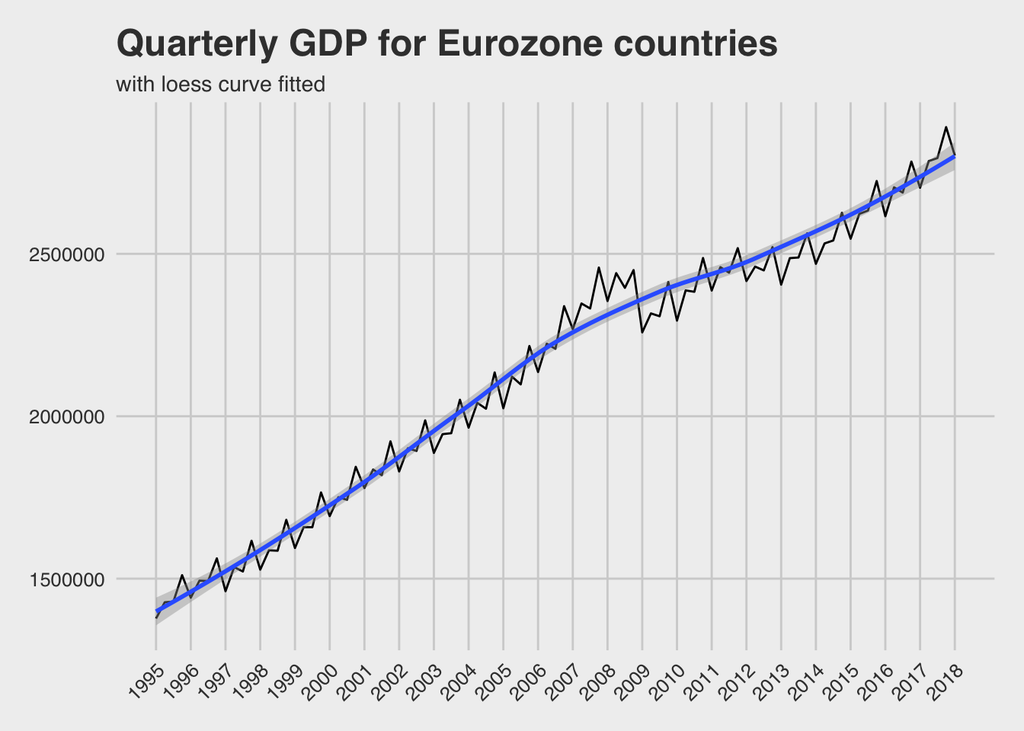

There are a few outputs from the time series plot above:  
- We can say that there is an overall positive trend  
- There is no obvious increased/decreased variability in the trend  
- It looks that there is some seasonality, but needs further investigation  
- There is no cyclicity  
- There is a major disruption in GDP growth around years 2008-9

To investigate seasonality, a seasonal plot is used below.

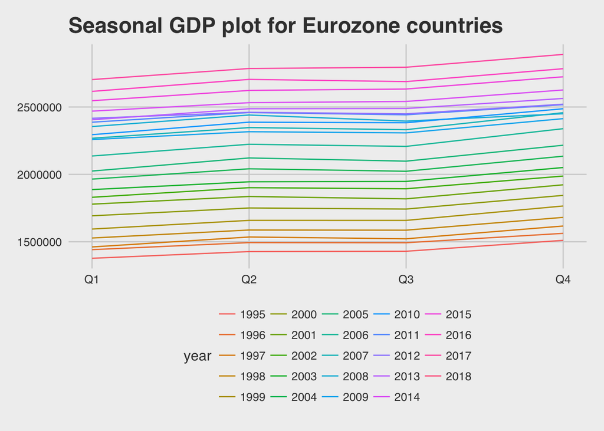

We are more confident now for the seasonality in the time series. It seems that 4th quarter is always the higher, while the 1st is always the lowest in each year. The 2nd & 3rd are about the same.

A lag plot would help us understand if there is autocorrelation in the time series. It is a scatterplot between the time series and the lagged values of the time series.

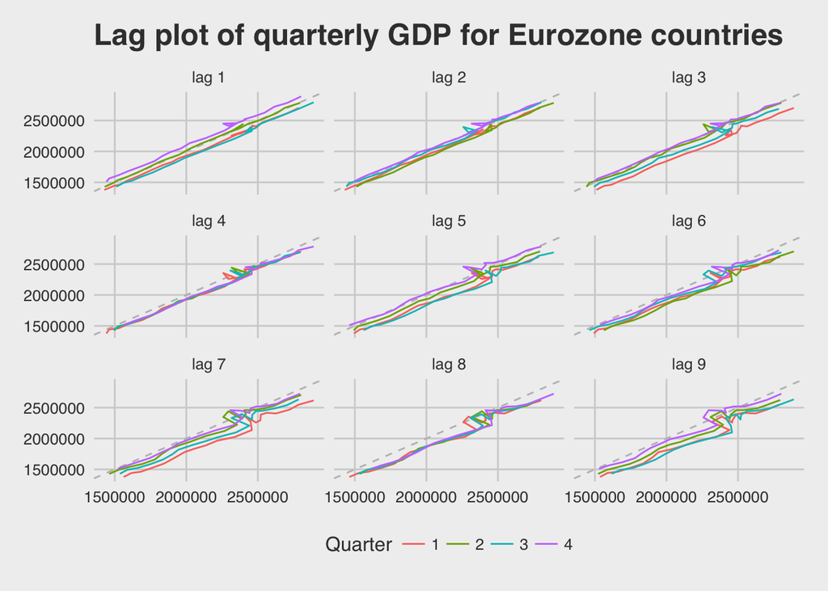

There is a strong seasonality at lag 4 (1 year), as all quarters line plots follow an almost identical path.

Below there is an autocorrelation function plot. It will indicate us if there are significant autocorellations in the time series.

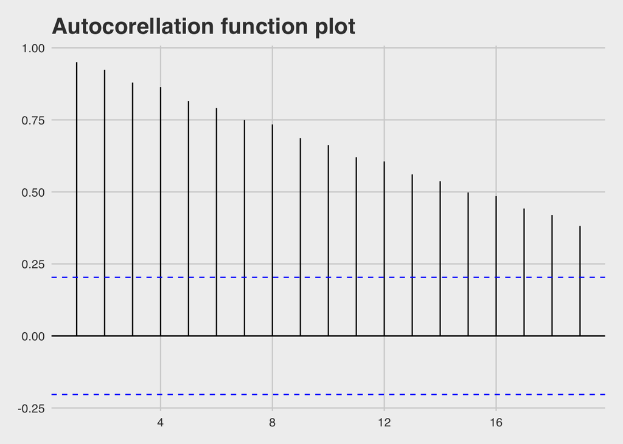

It looks that there are significant autocorellations at all lags, which indicates trend and/or seasonality in the time series.

We can also use Ljung-Box test to test if the time series is white noise. Below there is a test at lag 4.

```
##
##  Box-Ljung test
##
## data:  gdp_ts
## X-squared = 319.62, df = 4, p-value < 2.2e-16
```

Ljung-Box test p-value is very small < 0.01, so there is strong evidence that the time series is not white noise and has seasonality and/or trend.

# Modelling

ARIMA (Auto-regressive integrated moving average) models provide one of the main approaches to time series forecasting. It is the most widely-used approach to time series forecasting, and aim to describe the autocorrelations in the data.

After fitting the ARIMA model, it is important to check that the residuals are well-behaved (i.e., no outlines or patterns) and resemble white noise. Below there are some residual plots for the fitted ARIMA model.

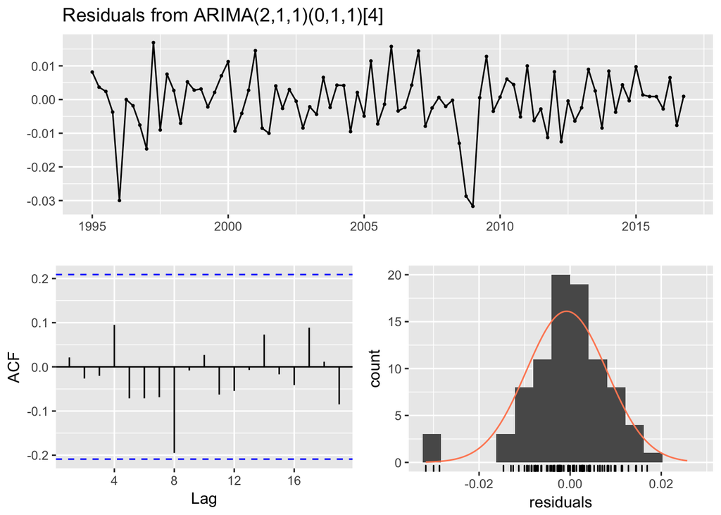

```
##
##  Ljung-Box test
##
## data:  Residuals from ARIMA(2,1,1)(0,1,1)[4]
## Q* = 6.1916, df = 4, p-value = 0.1853
##
## Model df: 4.   Total lags used: 8
```

We can say that the model is fairly good, since the residuals are closely normally distributed, have no real pattern and autocorrelations are not significant.  
The final model is **ARIMA(2,1,1)(0,1,1)[4]**. Both seasonal and first differences have been used, indicated by the middle slot in each part of the model. Also 1 lagged error and 1 seasonally lagged error have been selected, indicated by the last slot in each part of the model. 2 autoregression terms have been used, indicated by the first slot in the model. No seasonal autoregression terms have been used used.

Finally, the accuracy of the forecasting model is examined. Below there is a test for the model accuracy, using all four quarters in 2017 & the 1st quarter of 2018 as a test set

```
##                     ME     RMSE     MAE         MPE      MAPE      MASE
## Training set -1763.393 18524.64 13332.4 -0.08197817 0.6440916 0.1939318
## Test set     47152.498 49475.29 47152.5  1.68398118 1.6839812 0.6858757
##                    ACF1 Theil's U
## Training set 0.06526246        NA
## Test set     0.09563655 0.6768184
```

MAPE (Mean absolute percentage error) for the test set is 1.68, so we can conclude that the prediction accuracy of the model is around **98.3 %**.

Below there is a time series plot of the Eurozone countries quarterly GDP forecasts for 2018-19.

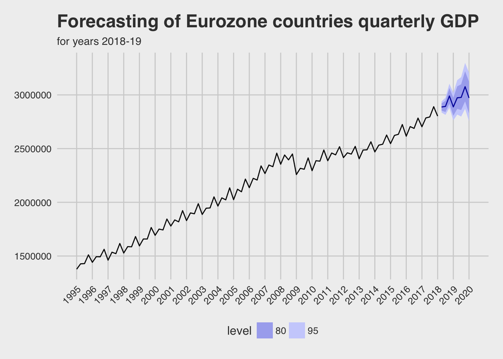